# Week 5 Assignment

[figure not shown]

### Question 1: Population Lines

#### A) 2010

**Use pandas to read a dataframe from the file `census_18.csv`. Then produce a line plot of the counts by age for the 2010 census, x-axis will be the series `age`, y-axis will be the census values for `2010`.**

```python
import pandas as pd
df = pd.read_csv('census_18.csv')
df.head() # Examine dataframe layout
```

|  | AGE | 2010 | 2014 |
| --- | --- | --- | --- |
| 0 | 0 | 3951330 | 3949775 |
| 1 | 1 | 3957888 | 3949776 |
| 2 | 2 | 4090862 | 3959664 |
| 3 | 3 | 4111920 | 4007079 |
| 4 | 4 | 4077551 | 4005716 |

[figure not shown]

```python
# Code and run your solution here

df.plot.line(x="AGE", y="2010", label="Born in 2014", c="blue")# Make a plot
```

#### B) 2014

Using your dataframe from exercise 5, plot both the 2010 and 2014 census values by age. Plot the 2010 distribution in blue and the 2014 distribution in red.

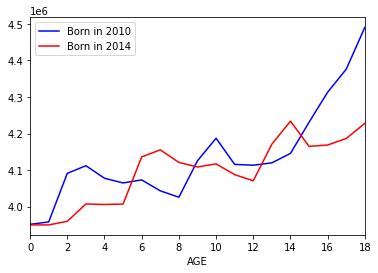

```python
ax = df.plot.line(x="AGE", y="2010", label="Born in 2010", c="blue")
df.plot.line(x="AGE", y="2014", label="Born in 2014", c="red", ax=ax)
```

#### C) Now with Matplotlip

Do B with matplotlib.

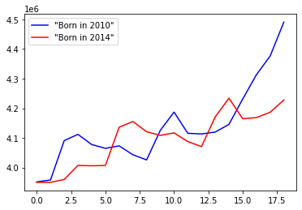

```python
import matplotlib.pyplot as plt

# dataframe already exists
age = df['AGE']
born2010 = df['2010']
born2014 = df['2014']

plt.plot(age, born2010, c='blue', label='"Born in 2010"')
plt.plot(age, born2014, c='red', label='"Born in 2014"')
plt.legend()
plt.show()
```

### Question2: Assume the following rules:

- If the dice shows 1 or 2 spots, my net gain is (-2*value of dice) dollars.
- If the dice shows 3 or 4 spots, my net gain is 1 dollars.
- If the dice shows 5 spots, my net gain is (2*value of dice) dollars.
- If the dice shows 6 spots, my net gain is -5 dollars.

```python
def D6game2(nrolls):
    import numpy as np                     #import numpy
    dice = np.array([1,2,3,4,5,6])         #create a numpy array with values of a D6
    rolls = np.random.choice(dice,nrolls)  #randomly selecting a value from dice for nrolls times- simulation
    gainlist =[]                           #create an empty list for gains|losses
    for i in np.arange(len(rolls)):        #Apply the rules
        if rolls[i]<=2:
            gainlist.append(-2*rolls[i])
        elif rolls[i]<=4:
            gainlist.append(+1)
        elif rolls[i]==5:
            gainlist.append(+2*rolls[i])
        elif rolls[i]==6:
            gainlist.append(-5)
    return (np.sum(gainlist))              #sum up all gains|losses
#   return (gainlist,"The net gain is equal to:",np.sum(gainlist))
```

```python
D6game2(5)
```

```
14
```

```python
D6game2(10)
```

```
22
```

```python
D6game2(50)
```

```
-13
```

[figure not shown]